# Exploration

# Setup and load data

```r
library(tidyverse)
library(janitor)
library(skimr)
library(GGally) # for ggpairs()
library(mosaic) # for plotModel()
library(modelr)
library(ggfortify) # for autoplot()
library(broom) # for tidy() and glance()
library(relaimpo) # for calc.relimp()
library(leaps) # for automated model building
# also use base summary() and stats lm()
```

```r
red_wine <- read_csv("data/wine_quality_red.csv")
white_wine <- read_csv("data/wine_quality_white.csv")
```

```r
skim(red_wine)
```

```
── Data Summary ────────────────────────
                           Values
Name                       red_wine
Number of rows             1599
Number of columns          14
_______________________
Column type frequency:
  character                1
  numeric                  13
________________________
Group variables            None
```

|  | skim_variable | n_missing | complete_rate | min | max | empty | n_unique | whitespace |
| --- | --- | --- | --- | --- | --- | --- | --- | --- |
| 1 | region | 0 | 1 | 3 | 9 | 0 | 5 | 0 |

|  | skim_variable | n_missing | complete_rate | mean | sd | p0 | p25 | p50 | p75 | p100 | hist |
| --- | --- | --- | --- | --- | --- | --- | --- | --- | --- | --- | --- |
| 1 | wine_id | 0 | 1 | 800.00000000 | 4.617359e+02 | 1.00000 | 400.5000 | 800.00000 | 1199.500000 | 1599.00000 | ▇▇▇▇▇ |
| 2 | fixed_acidity | 0 | 1 | 8.31963727 | 1.741096e+00 | 4.60000 | 7.1000 | 7.90000 | 9.200000 | 15.90000 | ▂▇▂▁▁ |
| 3 | volatile_acidity | 0 | 1 | 0.52782051 | 1.790597e-01 | 0.12000 | 0.3900 | 0.52000 | 0.640000 | 1.58000 | ▅▇▂▁▁ |
| 4 | citric_acid | 0 | 1 | 0.27097561 | 1.948011e-01 | 0.00000 | 0.0900 | 0.26000 | 0.420000 | 1.00000 | ▇▆▅▁▁ |
| 5 | residual_sugar | 0 | 1 | 2.53880550 | 1.409928e+00 | 0.90000 | 1.9000 | 2.20000 | 2.600000 | 15.50000 | ▇▁▁▁▁ |
| 6 | chlorides | 0 | 1 | 0.08746654 | 4.706530e-02 | 0.01200 | 0.0700 | 0.07900 | 0.090000 | 0.61100 | ▇▁▁▁▁ |
| 7 | free_sulfur_dioxide | 0 | 1 | 15.87492183 | 1.046016e+01 | 1.00000 | 7.0000 | 14.00000 | 21.000000 | 72.00000 | ▇▅▁▁▁ |
| 8 | total_sulfur_dioxide | 0 | 1 | 46.46779237 | 3.289532e+01 | 6.00000 | 22.0000 | 38.00000 | 62.000000 | 289.00000 | ▇▂▁▁▁ |
| 9 | density | 0 | 1 | 0.99674668 | 1.887334e-03 | 0.99007 | 0.9956 | 0.99675 | 0.997835 | 1.00369 | ▁▃▇▂▁ |
| 10 | p_h | 0 | 1 | 3.31111320 | 1.543865e-01 | 2.74000 | 3.2100 | 3.31000 | 3.400000 | 4.01000 | ▁▅▇▂▁ |

[output cut: 3 more lines]

~1600 (1599) observations 1 character variable: region 13 numeric variables:

- wine_id - can drop
- fixed_acidity - looks normally distributed but long right tail
- volatile_acidity
- citric_acid
- residual_sugar
- chlorides
- free_sulfur_dioxide
- total_sulfur_dioxide
- density - looks normally distributed from histo
- p_h - - looks normally distributed from histo (already a log scale scientifically)
- sulfates
- alcohol
- quality - this is **outcome / response** variable, looks normally distributed

Numeric variables are all continuous (not hidden ordinal), most are quite strongly right-skewed and may need transforming (using log)

```r
skim(white_wine)
```

```
── Data Summary ────────────────────────
                           Values
Name                       white_wine
Number of rows             4898
Number of columns          14
_______________________
Column type frequency:
  character                1
  numeric                  13
________________________
Group variables            None
```

|  | skim_variable | n_missing | complete_rate | min | max | empty | n_unique | whitespace |
| --- | --- | --- | --- | --- | --- | --- | --- | --- |
| 1 | region | 0 | 1 | 3 | 9 | 0 | 5 | 0 |

|  | skim_variable | n_missing | complete_rate | mean | sd | p0 | p25 | p50 | p75 | p100 | hist |
| --- | --- | --- | --- | --- | --- | --- | --- | --- | --- | --- | --- |
| 1 | wine_id | 0 | 1 | 2.449500e+03 | 1.414075e+03 | 1.00000 | 1225.2500000 | 2449.50000 | 3673.7500 | 4898.00000 | ▇▇▇▇▇ |
| 2 | fixed_acidity | 0 | 1 | 6.854788e+00 | 8.438682e-01 | 3.80000 | 6.3000000 | 6.80000 | 7.3000 | 14.20000 | ▁▇▁▁▁ |
| 3 | volatile_acidity | 0 | 1 | 2.782411e-01 | 1.007945e-01 | 0.08000 | 0.2100000 | 0.26000 | 0.3200 | 1.10000 | ▇▅▁▁▁ |
| 4 | citric_acid | 0 | 1 | 3.341915e-01 | 1.210198e-01 | 0.00000 | 0.2700000 | 0.32000 | 0.3900 | 1.66000 | ▇▆▁▁▁ |
| 5 | residual_sugar | 0 | 1 | 6.391415e+00 | 5.072058e+00 | 0.60000 | 1.7000000 | 5.20000 | 9.9000 | 65.80000 | ▇▁▁▁▁ |
| 6 | chlorides | 0 | 1 | 4.577236e-02 | 2.184797e-02 | 0.00900 | 0.0360000 | 0.04300 | 0.0500 | 0.34600 | ▇▁▁▁▁ |
| 7 | free_sulfur_dioxide | 0 | 1 | 3.530808e+01 | 1.700714e+01 | 2.00000 | 23.0000000 | 34.00000 | 46.0000 | 289.00000 | ▇▁▁▁▁ |
| 8 | total_sulfur_dioxide | 0 | 1 | 1.383607e+02 | 4.249806e+01 | 9.00000 | 108.0000000 | 134.00000 | 167.0000 | 440.00000 | ▂▇▂▁▁ |
| 9 | density | 0 | 1 | 9.940274e-01 | 2.990907e-03 | 0.98711 | 0.9917225 | 0.99374 | 0.9961 | 1.03898 | ▇▂▁▁▁ |
| 10 | p_h | 0 | 1 | 3.188267e+00 | 1.510006e-01 | 2.72000 | 3.0900000 | 3.18000 | 3.2800 | 3.82000 | ▁▇▇▂▁ |

[output cut: 3 more lines]

~5000 (4898) observations

# Modelling plan

Before looking any further or starting cleaning, first plan the modelling process

## Feature inclusion/exclusion:

- I will drop wine_id as it is not a predictor
- I will look at red and white wines separately, because I understand them to have different chemical properties and I am curious to see whether the same features are important for quality in both or not
- Region is a variable in both - I understand that many chemical properties of wines come about from the type of soil they’re grown in (as well as variety of grape and process), and region is a big factor in this. Instead of looking at region AND the chemical properties, I will not look at region. I may model for region alone at the end to see if there are any correlations / interactions with other variables.

## Model building process:

- Test/train split: As best practice, I will split train/test data using 10-fold cross validation, with ~160 observations in each test set for red, ~490 in white
- Cleaning & feature engineering: before split - transform where needed, check for NAs; after split - explore the variables and correlations, understand what the variables mean (see data dictionary, online search if time)
- Modelling method: I will use automated model building with best subsets as a first step to get an approximate model with main features Using caret::train() to set up K-fold CV, therefore train model (method “lm” for linear regression) this way, and then check the diagnostics and success measures for this model and consider adding/removing interactions to improve the model
- Measure: I’ll use BIC and adjusted R squared to assess which models are better; also the plots of residuals v fitted values to check whether the model explains the data well or if there is anything uneven
- Improve the model using manual stepwise regression, to also include potential interactions: check correlations between vars and also with vars and remaining residuals
- Test: Use the model to predict values in the test set - check RMSE to understand predictive accuracy
- Interpret: check relative importance, explain the model

# 1. Transform data

white_wine cleaning

- no NAs
- 19 0s in citric acid, to exclude when log transforming
- after log transformation –> only ln_alcohol histogram looks more normal, these transformations might not be useful
- remove citric acid transformation as this introduces missing values that prevents train() from working, and given citric acid data not much improved from the transformation anyway
- note from dictionary: “wines with greater than 45 grams/liter are considered sweet” –> should i recategorise any wines as sweet or not? No, assuming this white wine is not a dessert wine (it’s all “variants of the Portuguese “Vinho Verde” wine”)

```r
# find any 0 values in dataset, before log transform
colSums(white_wine == 0) # 19 in citric_acid
```

```
             wine_id        fixed_acidity     volatile_acidity          citric_acid       residual_sugar            chlorides
                   0                    0                    0                   19                    0                    0
 free_sulfur_dioxide total_sulfur_dioxide              density                  p_h            sulphates              alcohol
                   0                    0                    0                    0                    0                    0
             quality               region
                   0                    0
```

```r
white_wine %>%
  mutate(ln_volatile_acidity = log(volatile_acidity),
         ln_citric_acid = if_else(citric_acid != 0, log(citric_acid), NA_integer_),
         ln_residual_sugar = log(residual_sugar),
         ln_chlorides = log(chlorides),
         ln_free_sulfur_dioxide = log(free_sulfur_dioxide),
         ln_density = log(density),
         ln_sulphates = log(sulphates),
         ln_alcohol = log(alcohol)) %>%
  skim()
```

```
── Data Summary ────────────────────────
                           Values
Name                       Piped data
Number of rows             4898
Number of columns          22
_______________________
Column type frequency:
  character                1
  numeric                  21
________________________
Group variables            None
```

|  | skim_variable | n_missing | complete_rate | min | max | empty | n_unique | whitespace |
| --- | --- | --- | --- | --- | --- | --- | --- | --- |
| 1 | region | 0 | 1 | 3 | 9 | 0 | 5 | 0 |

|  | skim_variable | n_missing | complete_rate | mean | sd | p0 | p25 | p50 | p75 | p100 | hist |
| --- | --- | --- | --- | --- | --- | --- | --- | --- | --- | --- | --- |
| 1 | wine_id | 0 | 1.0000000 | 2.449500e+03 | 1.414075e+03 | 1.0000000 | 1.225250e+03 | 2.449500e+03 | 3.673750e+03 | 4898.00000000 | ▇▇▇▇▇ |
| 2 | fixed_acidity | 0 | 1.0000000 | 6.854788e+00 | 8.438682e-01 | 3.8000000 | 6.300000e+00 | 6.800000e+00 | 7.300000e+00 | 14.20000000 | ▁▇▁▁▁ |
| 3 | volatile_acidity | 0 | 1.0000000 | 2.782411e-01 | 1.007945e-01 | 0.0800000 | 2.100000e-01 | 2.600000e-01 | 3.200000e-01 | 1.10000000 | ▇▅▁▁▁ |
| 4 | citric_acid | 0 | 1.0000000 | 3.341915e-01 | 1.210198e-01 | 0.0000000 | 2.700000e-01 | 3.200000e-01 | 3.900000e-01 | 1.66000000 | ▇▆▁▁▁ |
| 5 | residual_sugar | 0 | 1.0000000 | 6.391415e+00 | 5.072058e+00 | 0.6000000 | 1.700000e+00 | 5.200000e+00 | 9.900000e+00 | 65.80000000 | ▇▁▁▁▁ |
| 6 | chlorides | 0 | 1.0000000 | 4.577236e-02 | 2.184797e-02 | 0.0090000 | 3.600000e-02 | 4.300000e-02 | 5.000000e-02 | 0.34600000 | ▇▁▁▁▁ |
| 7 | free_sulfur_dioxide | 0 | 1.0000000 | 3.530808e+01 | 1.700714e+01 | 2.0000000 | 2.300000e+01 | 3.400000e+01 | 4.600000e+01 | 289.00000000 | ▇▁▁▁▁ |
| 8 | total_sulfur_dioxide | 0 | 1.0000000 | 1.383607e+02 | 4.249806e+01 | 9.0000000 | 1.080000e+02 | 1.340000e+02 | 1.670000e+02 | 440.00000000 | ▂▇▂▁▁ |
| 9 | density | 0 | 1.0000000 | 9.940274e-01 | 2.990907e-03 | 0.9871100 | 9.917225e-01 | 9.937400e-01 | 9.961000e-01 | 1.03898000 | ▇▂▁▁▁ |
| 10 | p_h | 0 | 1.0000000 | 3.188267e+00 | 1.510006e-01 | 2.7200000 | 3.090000e+00 | 3.180000e+00 | 3.280000e+00 | 3.82000000 | ▁▇▇▂▁ |

[output cut: 11 more lines]

```r
white_wine_transform <- white_wine %>%
  mutate(ln_volatile_acidity = log(volatile_acidity),
         ln_residual_sugar = log(residual_sugar),
         ln_chlorides = log(chlorides),
         ln_free_sulfur_dioxide = log(free_sulfur_dioxide),
         ln_density = log(density),
         ln_sulphates = log(sulphates),
         ln_alcohol = log(alcohol)) %>%
  dplyr::select(-c(wine_id,region))
# note dplyr select masked by package MASS
```

# 2: Set up 10-fold CV and model with all vars

```r
white_wine_cv_10_fold <- trainControl(method = "cv", # cross-validation
                           number = 10, # 10-fold
                           savePredictions = TRUE) # save all predictions

model_ww10fold <- train(quality ~ .,
               data = white_wine_transform,
               trControl = white_wine_cv_10_fold,
               method = 'lm')
```

```r
summary(model_ww10fold)
```

```
Call:
lm(formula = .outcome ~ ., data = dat)

Residuals:
    Min      1Q  Median      3Q     Max
-3.4197 -0.5369 -0.0174  0.5030  3.1644

Coefficients:
                         Estimate Std. Error t value Pr(>|t|)
(Intercept)            -5.723e+03  1.100e+03  -5.203 2.04e-07 ***
fixed_acidity           1.175e-01  2.427e-02   4.842 1.32e-06 ***
volatile_acidity       -6.695e-02  4.307e-01  -0.155 0.876474
citric_acid             3.870e-02  1.008e-01   0.384 0.701096
residual_sugar          5.627e-02  1.069e-02   5.264 1.47e-07 ***
chlorides               2.365e+00  1.317e+00   1.795 0.072729 .
free_sulfur_dioxide    -1.888e-02  1.737e-03 -10.868  < 2e-16 ***
total_sulfur_dioxide   -7.457e-04  4.138e-04  -1.802 0.071595 .
density                 5.728e+03  1.100e+03   5.209 1.98e-07 ***
p_h                     8.474e-01  1.184e-01   7.156 9.56e-13 ***
sulphates               1.172e+00  6.259e-01   1.872 0.061229 .
alcohol                 7.614e-01  1.763e-01   4.320 1.59e-05 ***
ln_volatile_acidity    -5.739e-01  1.290e-01  -4.450 8.78e-06 ***
ln_residual_sugar       1.805e-01  3.933e-02   4.589 4.57e-06 ***
ln_chlorides           -2.201e-01  9.381e-02  -2.347 0.018988 *
ln_free_sulfur_dioxide  7.801e-01  5.340e-02  14.608  < 2e-16 ***
ln_density             -5.889e+03  1.107e+03  -5.321 1.08e-07 ***
ln_sulphates           -2.672e-01  3.204e-01  -0.834 0.404322
ln_alcohol             -7.079e+00  1.841e+00  -3.845 0.000122 ***
---
Signif. codes:  0 ‘***’ 0.001 ‘**’ 0.01 ‘*’ 0.05 ‘.’ 0.1 ‘ ’ 1

Residual standard error: 0.785 on 4879 degrees of freedom
Multiple R-squared:  0.306, Adjusted R-squared:  0.3034
F-statistic: 119.5 on 18 and 4879 DF,  p-value: < 2.2e-16
```

Note adj R2 is quite close to R2 suggesting this is not overfitted

Adj R2 is 0.3034

Model contains both ln_ and non-transformed versions of the same variables – pick the most significant one of each, and call this a subset…

```r
model_ww10fold$resample
```

| RMSE | Rsquared | MAE | Resample |
| --- | --- | --- | --- |
| 0.8155119 | 0.3151660 | 0.6391467 | Fold01 |
| 0.7644031 | 0.3211543 | 0.5985175 | Fold02 |
| 0.7707435 | 0.2817363 | 0.6099324 | Fold03 |
| 0.7796000 | 0.3019997 | 0.6249177 | Fold04 |
| 0.8231892 | 0.2272282 | 0.6438862 | Fold05 |
| 0.7836268 | 0.2969887 | 0.6177652 | Fold06 |
| 0.8265221 | 0.2940181 | 0.6441926 | Fold07 |
| 0.7682251 | 0.3328453 | 0.6001503 | Fold08 |
| 0.7772508 | 0.2978991 | 0.5981827 | Fold09 |
| 0.7767870 | 0.3144819 | 0.6232100 | Fold10 |

```r
mean(model_ww10fold$resample$RMSE)
```

```
[1] 0.788586
```

```r
plot(model_ww10fold)
```

```
Error in plot.train(model_ww10fold) :
  There are no tuning parameters with more than 1 value.
```

Cannot run diagnostic plots with autoplot() or plot() using a train() model output. Try manually? (actually it is possible, just need to feed in model$finalModel)

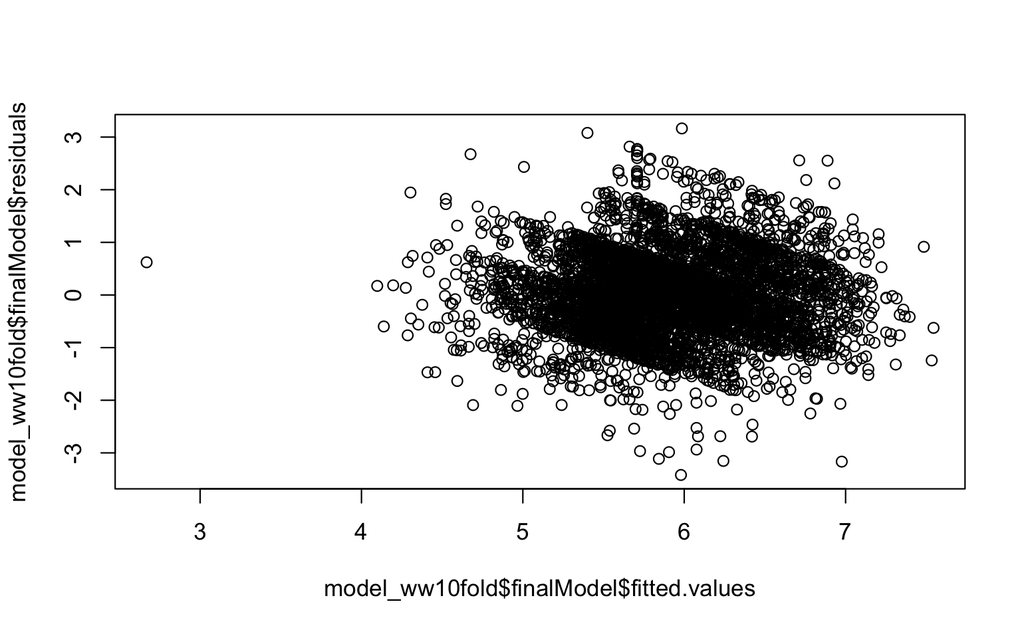

```r
# plot Residuals v Fitted values
plot(x = model_ww10fold$finalModel$fitted.values, y = model_ww10fold$finalModel$residuals)
```

Residuals v Fitted looks good, maybe 3 diagionals in there

Try keeping only normal or ln_ version of each variable (based on lowest p-value in model above):

```r
white_wine_transform2 <- white_wine %>%
  mutate(ln_volatile_acidity = log(volatile_acidity),
         ln_chlorides = log(chlorides),
         ln_density = log(density)) %>%
  dplyr::select(-c(wine_id,region,
                   volatile_acidity,chlorides,density))

white_wine_cv_10_fold <- trainControl(method = "cv", # cross-validation
                           number = 10, # 10-fold
                           savePredictions = TRUE) # save all predictions

model_ww10fold_2 <- train(quality ~ .,
               data = white_wine_transform2,
               trControl = white_wine_cv_10_fold,
               method = 'lm')
```

```r
summary(model_ww10fold_2)
```

```
Call:
lm(formula = .outcome ~ ., data = dat)

Residuals:
    Min      1Q  Median      3Q     Max
-3.6733 -0.5356 -0.0189  0.5085  3.2739

Coefficients:
                       Estimate Std. Error t value Pr(>|t|)
(Intercept)          -1.811e+00  4.493e-01  -4.030 5.66e-05 ***
fixed_acidity         7.285e-02  2.253e-02   3.233 0.001233 **
citric_acid           5.013e-02  1.022e-01   0.490 0.623897
residual_sugar        8.603e-02  8.177e-03  10.521  < 2e-16 ***
free_sulfur_dioxide   3.412e-03  9.080e-04   3.758 0.000173 ***
total_sulfur_dioxide -1.106e-04  4.102e-04  -0.270 0.787479
p_h                   7.347e-01  1.134e-01   6.477 1.03e-10 ***
sulphates             5.927e-01  1.078e-01   5.497 4.07e-08 ***
alcohol               1.882e-01  2.625e-02   7.169 8.66e-13 ***
ln_volatile_acidity  -6.009e-01  3.643e-02 -16.494  < 2e-16 ***
ln_chlorides         -5.568e-02  4.172e-02  -1.335 0.182045
ln_density           -1.589e+02  2.069e+01  -7.682 1.88e-14 ***
---
Signif. codes:  0 ‘***’ 0.001 ‘**’ 0.01 ‘*’ 0.05 ‘.’ 0.1 ‘ ’ 1

Residual standard error: 0.8069 on 4886 degrees of freedom
Multiple R-squared:  0.2658,    Adjusted R-squared:  0.2642
F-statistic: 160.8 on 11 and 4886 DF,  p-value: < 2.2e-16
```

- Again R2 and adj R2 quite similar, suggests not overfitting.
- Most features are significant, only citric acid, total sulfur dioxide and ln_chlorides are not.
- Adj R2 is lower than the previous model, 0.2642 v 0.3034 (but previous model was incorrect as accounted for some features twice - normal and ln_ versions)
- Residual std error also a bit higher, but quite small relative to the scale of the outcome variable (0.8 on 1-13 quality scale)

```r
model_ww10fold_2$resample
```

| RMSE | Rsquared | MAE | Resample |
| --- | --- | --- | --- |
| 0.8390099 | 0.2617493 | 0.6326598 | Fold01 |
| 0.8219817 | 0.2193867 | 0.6560674 | Fold02 |
| 0.7779409 | 0.3309339 | 0.6074529 | Fold03 |
| 0.8185846 | 0.2518506 | 0.6269094 | Fold04 |
| 0.8154962 | 0.2570524 | 0.6312995 | Fold05 |
| 0.7897214 | 0.2571788 | 0.6260172 | Fold06 |
| 0.8237691 | 0.2399289 | 0.6496999 | Fold07 |
| 0.7979010 | 0.2486654 | 0.6316710 | Fold08 |
| 0.7713166 | 0.3078936 | 0.6102536 | Fold09 |
| 0.8216582 | 0.2598323 | 0.6255540 | Fold10 |

Variability between the folds is quite low.

```r
mean(model_ww10fold_2$resample$RMSE)
```

```
[1] 0.807738
```

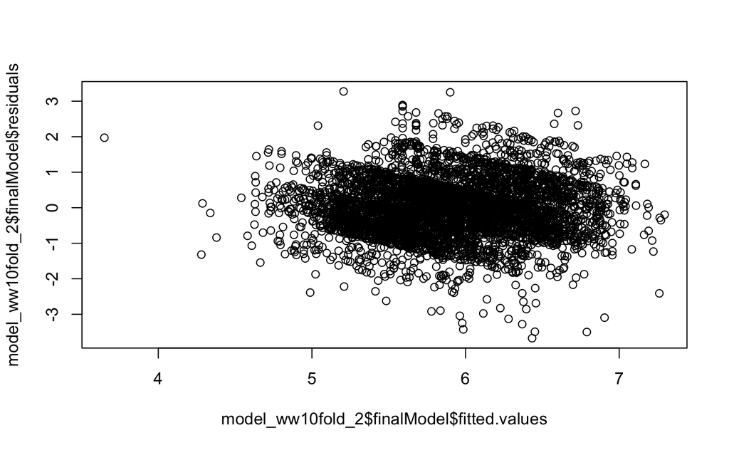

```r
plot(x = model_ww10fold_2$finalModel$fitted.values, y = model_ww10fold_2$finalModel$residuals)
```

Very similar plot to the previous model.

```r
broom::glance(model_ww10fold$finalModel) %>%  clean_names()
```

| r_squared | adj_r_squared | sigma | statistic | p_value | df | log_lik | aic | bic | deviance | df_residual | nobs |
| --- | --- | --- | --- | --- | --- | --- | --- | --- | --- | --- | --- |
| 0.3059784 | 0.3034179 | 0.7850475 | 119.5022 | 0 | 18 | -5755.072 | 11550.14 | 11680.08 | 3006.925 | 4879 | 4898 |

```r
broom::glance(model_ww10fold_2$finalModel) %>%  clean_names()
```

| r_squared | adj_r_squared | sigma | statistic | p_value | df | log_lik | aic | bic | deviance | df_residual | nobs |
| --- | --- | --- | --- | --- | --- | --- | --- | --- | --- | --- | --- |
| 0.2658038 | 0.2641509 | 0.8068711 | 160.8088 | 0 | 11 | -5892.885 | 11811.77 | 11896.23 | 3180.986 | 4886 | 4898 |

BIC:

- model 1: 11680.08
- model 2: 11896.23

Again, BIC is higher (thus worsE) in model 2 - but model 1 was not valid.

```r
autoplot(model_ww10fold_2$finalModel)
```

[output not shown]

Inspecting X278:

```r
white_wine_transform2[276:280,] %>%
  add_residuals(model_ww10fold_2)
```

| fixed_acidity | citric_acid | residual_sugar | free_sulfur_dioxide | total_sulfur_dioxide | p_h | sulphates | alcohol | quality | ln_volatile_acidity | ln_chlorides | ln_density | resid |
| --- | --- | --- | --- | --- | --- | --- | --- | --- | --- | --- | --- | --- |
| 6.6 | 0.41 | 8.9 | 51 | 169 | 3.14 | 0.57 | 9.8 | 6.40 | -1.660731 | -3.079114 | -0.004610613 | 0.39731715 |
| 6.7 | 0.41 | 9.1 | 50 | 166 | 3.14 | 0.58 | 9.8 | 5.52 | -1.609438 | -3.123566 | -0.004610613 | -0.48167326 |
| 7.7 | 0.40 | 1.1 | 9 | 60 | 2.89 | 0.50 | 10.6 | 4.96 | -1.347074 | -3.170086 | -0.008536331 | -0.68580893 |
| 6.8 | 0.34 | 1.2 | 14 | 67 | 3.05 | 0.47 | 10.6 | 3.73 | -1.139434 | -3.123566 | -0.008132983 | -1.78043432 |
| 7.0 | 0.49 | 4.7 | 17 | 105 | 3.26 | 0.68 | 12.4 | 6.54 | -1.203973 | -3.324236 | -0.008435479 | -0.01518312 |

Nothing looks strange about this row - no reason to consider it an outlier. Leave it as is.

# 3: Improve the model

Starting with the model from 10-fold CV (model 2), can I improve on this?

With all vars in (some ln_, some not)

- Use backwards stepwise regression to remove vars.
- Also check for potential interactions to consider

## Check for interactions

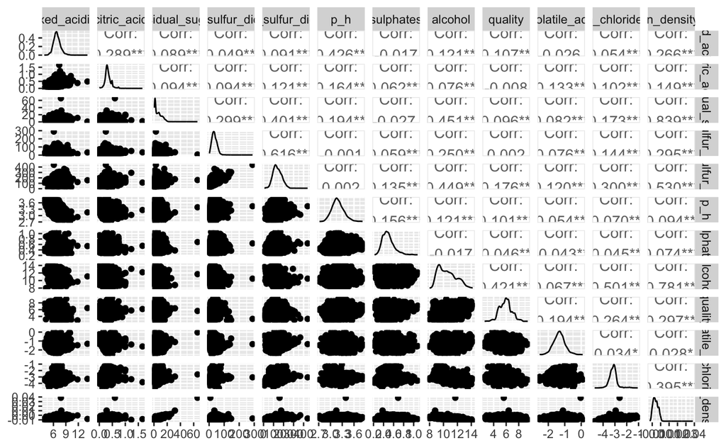

Look to be some correlations between sugar, density, alcohol, total sulfur dioxide as well as pH and fixed acidity

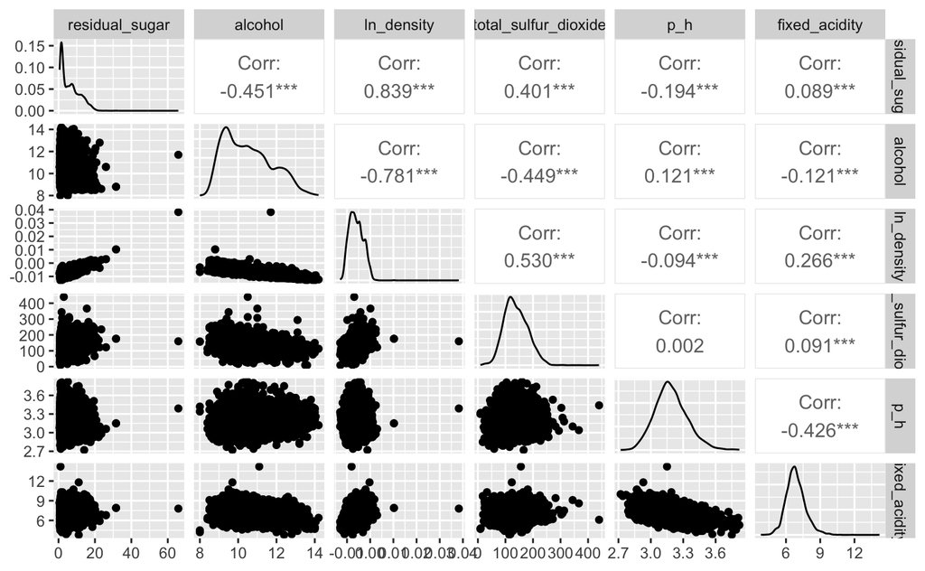

```r
white_wine_transform2 %>%
  dplyr::select(residual_sugar, alcohol, ln_density, total_sulfur_dioxide, p_h, fixed_acidity) %>%
  ggpairs()
```

Add to the variables in the current model:

residual_sugar:ln_density alcohol:ln_density total_sulfur_dioxide:ln_density alcohol:residual_sugar alcohol:total_sulfur_dioxide total_sulfur_dioxide:residual_sugar

plus

p_h:fixed_acidity

Density as an interaction with alcohol and sugar makes sense - alcohol and sugar change the “thickness” feeling of the wine pH and fixed acidity relationship also makes sense - pH is a measure of acidity

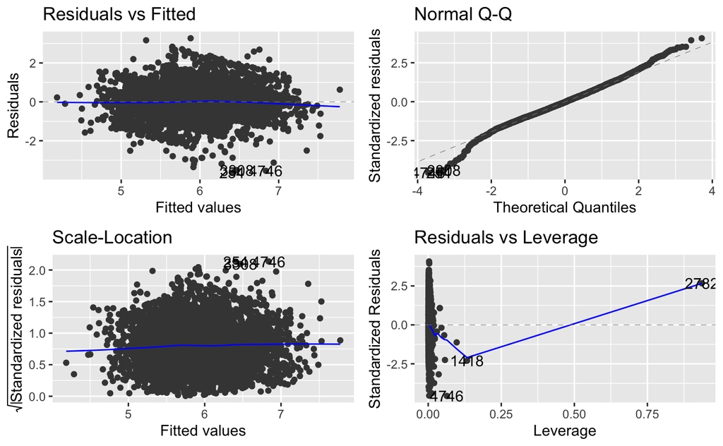

```r
autoplot(model_ww3)
```

[output not shown]

These plots look good, no worse than model 2. Still got a larger deviations from normal Q-Q at the lower extreme, suggesting our residuals distribution is skewed somewhat.

Looks like the high leverage observation is row 2782 not 278

```r
white_wine_transform2[2780:2784,]
```

| fixed_acidity | citric_acid | residual_sugar | free_sulfur_dioxide | total_sulfur_dioxide | p_h | sulphates | alcohol | quality | ln_volatile_acidity | ln_chlorides | ln_density |
| --- | --- | --- | --- | --- | --- | --- | --- | --- | --- | --- | --- |
| 6.7 | 0.37 | 1.65 | 42 | 103 | 3.11 | 0.45 | 11.4 | 5.37 | -1.60943791 | -3.688879 | -0.009828138 |
| 6.2 | 0.34 | 1.90 | 4 | 117 | 3.40 | 0.44 | 12.2 | 4.96 | -1.44816976 | -3.324236 | -0.009727156 |
| 7.8 | 0.60 | 65.80 | 8 | 160 | 3.39 | 0.69 | 11.7 | 5.62 | -0.03562718 | -2.603690 | 0.038239463 |
| 7.1 | 0.31 | 6.85 | 32 | 211 | 3.31 | 0.59 | 10.4 | 5.91 | -1.60943791 | -2.937463 | -0.004138552 |
| 7.1 | 0.31 | 7.40 | 32 | 211 | 3.31 | 0.59 | 10.4 | 5.57 | -1.60943791 | -2.937463 | -0.004138552 |

Looks like pretty high residual sugar from this snapshot

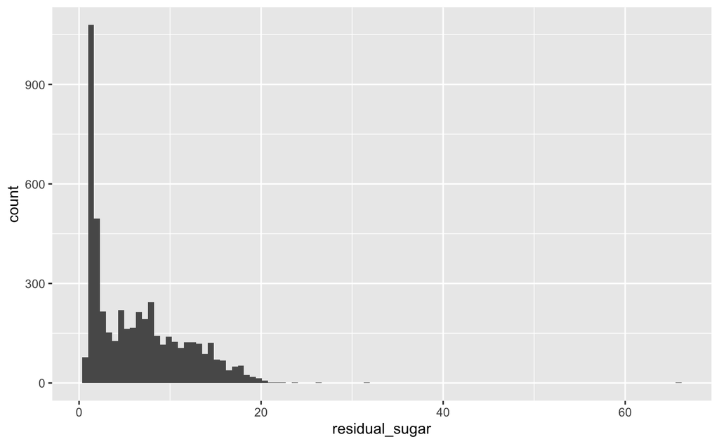

```r
white_wine_transform2 %>%
  ggplot(aes(x = residual_sugar)) +
  geom_histogram(bins = 100)
```

This shows one bin out above 60 - looks like this row is the max sugar, and is abnormally high - “wines with greater than 45 grams/liter are considered sweet” so maybe this is a particularly sweet wine. Still keeping in for now, would be good to be able to predict it.

```r
summary(model_ww3)
```

```
Call:
lm(formula = quality ~ . + residual_sugar:ln_density + alcohol:ln_density +
    total_sulfur_dioxide:ln_density + alcohol:residual_sugar +
    alcohol:total_sulfur_dioxide + total_sulfur_dioxide:residual_sugar +
    p_h:fixed_acidity, data = white_wine_transform2)

Residuals:
    Min      1Q  Median      3Q     Max
-3.5632 -0.5329 -0.0247  0.5045  3.2233

Coefficients:
                                      Estimate Std. Error t value Pr(>|t|)
(Intercept)                          9.495e+00  2.035e+00   4.665 3.17e-06 ***
fixed_acidity                       -9.343e-01  2.562e-01  -3.647 0.000269 ***
citric_acid                          2.210e-02  1.022e-01   0.216 0.828792
residual_sugar                      -5.744e-02  5.146e-02  -1.116 0.264384
free_sulfur_dioxide                  3.052e-03  9.090e-04   3.358 0.000792 ***
total_sulfur_dioxide                -9.058e-03  3.701e-03  -2.447 0.014428 *
p_h                                 -1.363e+00  5.536e-01  -2.461 0.013876 *
sulphates                            6.648e-01  1.092e-01   6.089 1.22e-09 ***
alcohol                             -3.053e-01  1.032e-01  -2.958 0.003107 **
ln_volatile_acidity                 -6.140e-01  3.729e-02 -16.468  < 2e-16 ***
ln_chlorides                        -7.924e-02  4.189e-02  -1.892 0.058584 .
ln_density                           2.266e+02  9.316e+01   2.432 0.015049 *
residual_sugar:ln_density            1.452e+00  3.785e-01   3.836 0.000127 ***
alcohol:ln_density                  -3.776e+01  6.796e+00  -5.557 2.90e-08 ***
total_sulfur_dioxide:ln_density     -2.620e-01  3.200e-01  -0.819 0.412963
residual_sugar:alcohol               1.451e-02  4.108e-03   3.531 0.000418 ***
total_sulfur_dioxide:alcohol         7.042e-04  4.890e-04   1.440 0.149969
residual_sugar:total_sulfur_dioxide  5.327e-05  1.378e-04   0.386 0.699152
fixed_acidity:p_h                    3.298e-01  8.086e-02   4.078 4.61e-05 ***
---
Signif. codes:  0 ‘***’ 0.001 ‘**’ 0.01 ‘*’ 0.05 ‘.’ 0.1 ‘ ’ 1

Residual standard error: 0.8023 on 4879 degrees of freedom
Multiple R-squared:  0.2751,    Adjusted R-squared:  0.2724
F-statistic: 102.9 on 18 and 4879 DF,  p-value: < 2.2e-16
```

Adj R2 is only slightly lower than R2, suggests still not overfitting

```r
BIC(model_ww3)
```

```
[1] 11893.48
```

```r
white_wine_transform2 %>%
  add_predictions(model_ww3) %>%
  mutate(error = quality - pred,
         sq_error = error^2) %>%
  summarise(RMSE = sqrt(mean(sq_error)))
```

| RMSE |
| --- |
| 0.8007799 |

Comparing models:

[output not shown]

Model 3 has higher adj R2, lower residual standard error and RMSE and lower BIC. So this is the best model yet, and also the one with the most predictors, which we could start to reduce and see if we can find the simplest model that is still as good as (if not better than) this one.

## Consider remaining residuals

[output not shown]

[output cut: 990 more lines]

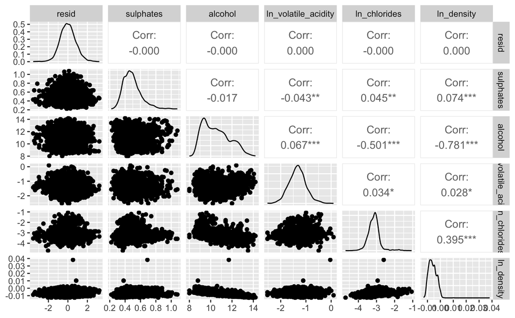

```r
white_wine_transform2 %>%
  add_residuals(model_ww3) %>%
  dplyr::select(resid, 7:12, -quality) %>%
  ggpairs()
```

None of these correlate with residual either – all variables are accounted for in model so no remaining residual can be reduced by adding in any variable (other than interactions, which I’ve already added for the most strongly correlated variables)

# Explain current model

Best model right now is model 3.

```r
summary(model_ww3)
```

```
Call:
lm(formula = quality ~ . + residual_sugar:ln_density + alcohol:ln_density +
    total_sulfur_dioxide:ln_density + alcohol:residual_sugar +
    alcohol:total_sulfur_dioxide + total_sulfur_dioxide:residual_sugar +
    p_h:fixed_acidity, data = white_wine_transform2)

Residuals:
    Min      1Q  Median      3Q     Max
-3.5632 -0.5329 -0.0247  0.5045  3.2233

Coefficients:
                                      Estimate Std. Error t value Pr(>|t|)
(Intercept)                          9.495e+00  2.035e+00   4.665 3.17e-06 ***
fixed_acidity                       -9.343e-01  2.562e-01  -3.647 0.000269 ***
citric_acid                          2.210e-02  1.022e-01   0.216 0.828792
residual_sugar                      -5.744e-02  5.146e-02  -1.116 0.264384
free_sulfur_dioxide                  3.052e-03  9.090e-04   3.358 0.000792 ***
total_sulfur_dioxide                -9.058e-03  3.701e-03  -2.447 0.014428 *
p_h                                 -1.363e+00  5.536e-01  -2.461 0.013876 *
sulphates                            6.648e-01  1.092e-01   6.089 1.22e-09 ***
alcohol                             -3.053e-01  1.032e-01  -2.958 0.003107 **
ln_volatile_acidity                 -6.140e-01  3.729e-02 -16.468  < 2e-16 ***
ln_chlorides                        -7.924e-02  4.189e-02  -1.892 0.058584 .
ln_density                           2.266e+02  9.316e+01   2.432 0.015049 *
residual_sugar:ln_density            1.452e+00  3.785e-01   3.836 0.000127 ***
alcohol:ln_density                  -3.776e+01  6.796e+00  -5.557 2.90e-08 ***
total_sulfur_dioxide:ln_density     -2.620e-01  3.200e-01  -0.819 0.412963
residual_sugar:alcohol               1.451e-02  4.108e-03   3.531 0.000418 ***
total_sulfur_dioxide:alcohol         7.042e-04  4.890e-04   1.440 0.149969
residual_sugar:total_sulfur_dioxide  5.327e-05  1.378e-04   0.386 0.699152
fixed_acidity:p_h                    3.298e-01  8.086e-02   4.078 4.61e-05 ***
---
Signif. codes:  0 ‘***’ 0.001 ‘**’ 0.01 ‘*’ 0.05 ‘.’ 0.1 ‘ ’ 1

Residual standard error: 0.8023 on 4879 degrees of freedom
Multiple R-squared:  0.2751,    Adjusted R-squared:  0.2724
F-statistic: 102.9 on 18 and 4879 DF,  p-value: < 2.2e-16
```

This model’s formula is:

> white wine quality = 9.495 - 0.934 fixed_acidity + 0.022 citric_acid - 0.057 residual_sugar + 0.003 free_sulfur_dioxide - 0.009 total_sulfur_dioxide - 1.3 p_h + 0.665 sulphates - 0.305 alcohol - 0.614 ln_volatile_acidity - 0.079 ln_chlorides + (226.6 + 1.452 residual_sugar - 37.76 alcohol - 0.262 total_sulfur_dioxide) * ln_density + 0.015 residual_sugar * alcohol + 0.0007 total_sulfur_dioxide * alcohol + 0.00005 residual_sugar * total_sulfur_dioxide + 0.330 fixed_acidity * p_h

## Reduce variables - WIP

Let’s take model 3 and start removing non-significant predictors one by one

```r
summary(model_ww3)
```

```
Call:
lm(formula = quality ~ . + residual_sugar:ln_density + alcohol:ln_density +
    total_sulfur_dioxide:ln_density + alcohol:residual_sugar +
    alcohol:total_sulfur_dioxide + total_sulfur_dioxide:residual_sugar +
    p_h:fixed_acidity, data = white_wine_transform2)

Residuals:
    Min      1Q  Median      3Q     Max
-3.5632 -0.5329 -0.0247  0.5045  3.2233

Coefficients:
                                      Estimate Std. Error t value Pr(>|t|)
(Intercept)                          9.495e+00  2.035e+00   4.665 3.17e-06 ***
fixed_acidity                       -9.343e-01  2.562e-01  -3.647 0.000269 ***
citric_acid                          2.210e-02  1.022e-01   0.216 0.828792
residual_sugar                      -5.744e-02  5.146e-02  -1.116 0.264384
free_sulfur_dioxide                  3.052e-03  9.090e-04   3.358 0.000792 ***
total_sulfur_dioxide                -9.058e-03  3.701e-03  -2.447 0.014428 *
p_h                                 -1.363e+00  5.536e-01  -2.461 0.013876 *
sulphates                            6.648e-01  1.092e-01   6.089 1.22e-09 ***
alcohol                             -3.053e-01  1.032e-01  -2.958 0.003107 **
ln_volatile_acidity                 -6.140e-01  3.729e-02 -16.468  < 2e-16 ***
ln_chlorides                        -7.924e-02  4.189e-02  -1.892 0.058584 .
ln_density                           2.266e+02  9.316e+01   2.432 0.015049 *
residual_sugar:ln_density            1.452e+00  3.785e-01   3.836 0.000127 ***
alcohol:ln_density                  -3.776e+01  6.796e+00  -5.557 2.90e-08 ***
total_sulfur_dioxide:ln_density     -2.620e-01  3.200e-01  -0.819 0.412963
residual_sugar:alcohol               1.451e-02  4.108e-03   3.531 0.000418 ***
total_sulfur_dioxide:alcohol         7.042e-04  4.890e-04   1.440 0.149969
residual_sugar:total_sulfur_dioxide  5.327e-05  1.378e-04   0.386 0.699152
fixed_acidity:p_h                    3.298e-01  8.086e-02   4.078 4.61e-05 ***
---
Signif. codes:  0 ‘***’ 0.001 ‘**’ 0.01 ‘*’ 0.05 ‘.’ 0.1 ‘ ’ 1

Residual standard error: 0.8023 on 4879 degrees of freedom
Multiple R-squared:  0.2751,    Adjusted R-squared:  0.2724
F-statistic: 102.9 on 18 and 4879 DF,  p-value: < 2.2e-16
```

### model 4: remove citric acid

```r
model_ww4 <- lm(quality ~ fixed_acidity + residual_sugar + free_sulfur_dioxide + total_sulfur dioxide + p_h + sulfates + alcohol + ln_volatile_acidity + ln_chlorides + ln_density + residual_sugar:ln_density + alcohol:ln_density + total_sulfur_dioxide:ln_density + alcohol:residual_sugar + alcohol:total_sulfur_dioxide + total_sulfur_dioxide:residual_sugar + p_h:fixed_acidity, data = white_wine_transform2)
```

```
Error: unexpected symbol in "model_ww4 <- lm(quality ~ fixed_acidity + residual_sugar + free_sulfur_dioxide + total_sulfur dioxide"
```

(Stopping here)

Qs for homework review:

- how to measure prediction accuracy?
- what does RSME tell us (that’s different to residual std error)?
- any other packages to use for K-fold CV (or how to do best subsets with this)? are there other packages that let me split and train separately?
- is it valid to pick log v not based on p-value in model with both in?

# homework review

- don’t forget alias() to check for variables saying the same thing - tbc if var and ln_var show up as aliases, they might not
- look at region v quality before just chucking region out
- resid = actual - pred
- log with 0s - add 1 to it to make this work, log(var+1)
- could write a function for ln_var = log(var) to use in mutate, or specify colnames using .names arguemnt in across: `mutate(across(.cols = where(is.numeric), .fns = ~ log(1 + .x), .names = "log_{.col}"))`